# DRD_2026_Lesson_3

```r
rm(list=ls())
setwd("~/Dropbox/DRD_2026/3")
suppressMessages(library(minfi))
suppressMessages(library(minfiData))
vignette("minfi")
```

```
## starting httpd help server ... done
```

# CHUNK 1: Import raw data

List the files included in the folder ~/Dropbox/DRD_2026/3/Input_Data

```r
list.files("~/Dropbox/DRD_2026/3/Input_Data")
```

```
##  [1] "9344737127_R01C02_Grn.idat" "9344737127_R01C02_Red.idat"
##  [3] "9344737127_R02C02_Grn.idat" "9344737127_R02C02_Red.idat"
##  [5] "9344737127_R03C02_Grn.idat" "9344737127_R03C02_Red.idat"
##  [7] "9344737127_R06C01_Grn.idat" "9344737127_R06C01_Red.idat"
##  [9] "9376538140_R01C01_Grn.idat" "9376538140_R01C01_Red.idat"
## [11] "9376538140_R02C01_Grn.idat" "9376538140_R02C01_Red.idat"
## [13] "9376538140_R04C01_Grn.idat" "9376538140_R04C01_Red.idat"
## [15] "9376538140_R05C01_Grn.idat" "9376538140_R05C01_Red.idat"
## [17] "SampleSheet.csv"
```

Let’s have a look at the csv

```r
SampleSheet <- read.table("~/Dropbox/DRD_2026/3/Input_Data/SampleSheet.csv",sep=",",header=T)
SampleSheet
```

```
##   Sample_ID Sample_Well  Array      Slide Group Gender   BMI
## 1     21050         G10 R01C02 9344737127     A      F 21.64
## 2     21060         A11 R03C02 9344737127     A      F 20.82
## 3     22041         F10 R06C01 9344737127     B      F 26.57
## 4     22051         H10 R02C02 9344737127     B      F 26.56
## 5     21090         F11 R02C01 9376538140     A      F 17.51
## 6     21100         A12 R05C01 9376538140     A      F 24.56
## 7     23081         E11 R01C01 9376538140     B      F 22.15
## 8     23091         H11 R04C01 9376538140     B      M 23.53
```

or

```r
SampleSheet <- read.csv("~/Dropbox/DRD_2026/3/Input_Data/SampleSheet.csv",header=T)
SampleSheet
```

```
##   Sample_ID Sample_Well  Array      Slide Group Gender   BMI
## 1     21050         G10 R01C02 9344737127     A      F 21.64
## 2     21060         A11 R03C02 9344737127     A      F 20.82
## 3     22041         F10 R06C01 9344737127     B      F 26.57
## 4     22051         H10 R02C02 9344737127     B      F 26.56
## 5     21090         F11 R02C01 9376538140     A      F 17.51
## 6     21100         A12 R05C01 9376538140     A      F 24.56
## 7     23081         E11 R01C01 9376538140     B      F 22.15
## 8     23091         H11 R04C01 9376538140     B      M 23.53
```

Set the directory in which the raw data are stored and load the samplesheet using the function read.metharray.sheet

```r
baseDir <- ("~/Dropbox/DRD_2026/3/Input_data")
targets <- read.metharray.sheet(baseDir)
```

```
## [read.metharray.sheet] Found the following CSV files:
```

```
## [1] "/Users/francesco/Dropbox/DRD_2026/3/Input_data/SampleSheet.csv"
```

```r
targets
```

```
##   Sample_ID Sample_Well  Array      Slide Group Gender   BMI
## 1     21050         G10 R01C02 9344737127     A      F 21.64
## 2     21060         A11 R03C02 9344737127     A      F 20.82
## 3     22041         F10 R06C01 9344737127     B      F 26.57
## 4     22051         H10 R02C02 9344737127     B      F 26.56
## 5     21090         F11 R02C01 9376538140     A      F 17.51
## 6     21100         A12 R05C01 9376538140     A      F 24.56
## 7     23081         E11 R01C01 9376538140     B      F 22.15
## 8     23091         H11 R04C01 9376538140     B      M 23.53
##                                                           Basename
## 1 /Users/francesco/Dropbox/DRD_2026/3/Input_data/9344737127_R01C02
## 2 /Users/francesco/Dropbox/DRD_2026/3/Input_data/9344737127_R03C02
## 3 /Users/francesco/Dropbox/DRD_2026/3/Input_data/9344737127_R06C01
## 4 /Users/francesco/Dropbox/DRD_2026/3/Input_data/9344737127_R02C02
## 5 /Users/francesco/Dropbox/DRD_2026/3/Input_data/9376538140_R02C01
## 6 /Users/francesco/Dropbox/DRD_2026/3/Input_data/9376538140_R05C01
## 7 /Users/francesco/Dropbox/DRD_2026/3/Input_data/9376538140_R01C01
## 8 /Users/francesco/Dropbox/DRD_2026/3/Input_data/9376538140_R04C01
```

Create an object of class RGChannelSet using the function read.metharray.exp

```r
?read.metharray.exp
RGset <- read.metharray.exp(targets = targets)
save(RGset,file="RGset.RData")
```

Let’s explore the RGset object:

```r
RGset
```

```
## class: RGChannelSet
## dim: 622399 8
## metadata(0):
## assays(2): Green Red
## rownames(622399): 10600313 10600322 ... 74810490 74810492
## rowData names(0):
## colnames(8): 9344737127_R01C02 9344737127_R03C02 ... 9376538140_R01C01
##   9376538140_R04C01
## colData names(9): Sample_ID Sample_Well ... Basename filenames
## Annotation
##   array: IlluminaHumanMethylation450k
##   annotation: ilmn12.hg19
```

```r
str(RGset)
```

```
## Formal class 'RGChannelSet' [package "minfi"] with 6 slots
##   ..@ annotation     : Named chr [1:2] "IlluminaHumanMethylation450k" "ilmn12.hg19"
##   .. ..- attr(*, "names")= chr [1:2] "array" "annotation"
##   ..@ colData        :Formal class 'DFrame' [package "S4Vectors"] with 6 slots
##   .. .. ..@ rownames       : chr [1:8] "9344737127_R01C02" "9344737127_R03C02" "9344737127_R06C01" "9344737127_R02C02" ...
##   .. .. ..@ nrows          : int 8
##   .. .. ..@ elementType    : chr "ANY"
##   .. .. ..@ elementMetadata: NULL
##   .. .. ..@ metadata       : list()
##   .. .. ..@ listData       :List of 9
##   .. .. .. ..$ Sample_ID  : int [1:8] 21050 21060 22041 22051 21090 21100 23081 23091
##   .. .. .. ..$ Sample_Well: chr [1:8] "G10" "A11" "F10" "H10" ...
##   .. .. .. ..$ Array      : chr [1:8] "R01C02" "R03C02" "R06C01" "R02C02" ...
##   .. .. .. ..$ Slide      : chr [1:8] "9344737127" "9344737127" "9344737127" "9344737127" ...
##   .. .. .. ..$ Group      : chr [1:8] "A" "A" "B" "B" ...
##   .. .. .. ..$ Gender     : chr [1:8] "F" "F" "F" "F" ...
##   .. .. .. ..$ BMI        : num [1:8] 21.6 20.8 26.6 26.6 17.5 ...
##   .. .. .. ..$ Basename   : chr [1:8] "/Users/francesco/Dropbox/DRD_2026/3/Input_data/9344737127_R01C02" "/Users/francesco/Dropbox/DRD_2026/3/Input_data/9344737127_R03C02" "/Users/francesco/Dropbox/DRD_2026/3/Input_data/9344737127_R06C01" "/Users/francesco/Dropbox/DRD_2026/3/Input_data/9344737127…
##   .. .. .. ..$ filenames  : chr [1:8] "/Users/francesco/Dropbox/DRD_2026/3/Input_data/9344737127_R01C02" "/Users/francesco/Dropbox/DRD_2026/3/Input_data/9344737127_R03C02" "/Users/francesco/Dropbox/DRD_2026/3/Input_data/9344737127_R06C01" "/Users/francesco/Dropbox/DRD_2026/3/Input_data/9344737127…
##   ..@ assays         :Formal class 'SimpleAssays' [package "SummarizedExperiment"] with 1 slot
##   .. .. ..@ data:Formal class 'SimpleList' [package "S4Vectors"] with 4 slots
##   .. .. .. .. ..@ listData       :List of 2
##   .. .. .. .. .. ..$ Green: int [1:622399, 1:8] 274 6329 1548 2000 1815 3046 1090 759 3482 209 ...
##   .. .. .. .. .. .. ..- attr(*, "dimnames")=List of 2
##   .. .. .. .. .. .. .. ..$ : chr [1:622399] "10600313" "10600322" "10600328" "10600336" ...
##   .. .. .. .. .. .. .. ..$ : chr [1:8] "9344737127_R01C02" "9344737127_R03C02" "9344737127_R06C01" "9344737127_R02C02" ...
##   .. .. .. .. .. ..$ Red  : int [1:622399, 1:8] 526 1807 1189 14881 6328 1070 351 12889 610 328 ...
##   .. .. .. .. .. .. ..- attr(*, "dimnames")=List of 2
##   .. .. .. .. .. .. .. ..$ : chr [1:622399] "10600313" "10600322" "10600328" "10600336" ...
##   .. .. .. .. .. .. .. ..$ : chr [1:8] "9344737127_R01C02" "9344737127_R03C02" "9344737127_R06C01" "9344737127_R02C02" ...
##   .. .. .. .. ..@ elementType    : chr "ANY"
##   .. .. .. .. ..@ elementMetadata: NULL
##   .. .. .. .. ..@ metadata       : list()
##   ..@ NAMES          : chr [1:622399] "10600313" "10600322" "10600328" "10600336" ...
##   ..@ elementMetadata:Formal class 'DFrame' [package "S4Vectors"] with 6 slots
##   .. .. ..@ rownames       : NULL
##   .. .. ..@ nrows          : int 622399
##   .. .. ..@ elementType    : chr "ANY"
##   .. .. ..@ elementMetadata: NULL
##   .. .. ..@ metadata       : list()
##   .. .. ..@ listData       : Named list()
##   ..@ metadata       : list()
```

```r
?RGChannelSet
```

We extract the Green and Red Channels using the functions getGreen and getRed

```r
Red <- data.frame(getRed(RGset))
dim(Red)
```

```
## [1] 622399      8
```

```r
head(Red)
```

```
##          X9344737127_R01C02 X9344737127_R03C02 X9344737127_R06C01
## 10600313                526                556                660
## 10600322               1807               1457               1369
## 10600328               1189               1279               1120
## 10600336              14881              14211              14680
## 10600345               6328               4476               4010
## 10600353               1070               1005                982
##          X9344737127_R02C02 X9376538140_R02C01 X9376538140_R05C01
## 10600313                641                483                652
## 10600322               1914               1649               2325
## 10600328               1129               1763               1621
## 10600336              15868              15747              15581
## 10600345               6040               6398               5747
## 10600353               1196               1139                954
##          X9376538140_R01C01 X9376538140_R04C01
## 10600313                618                661
## 10600322               1840               1599
## 10600328               1796               1706
## 10600336              14770              15405
## 10600345               4541               4433
## 10600353                911               1044
```

```r
Green <- data.frame(getGreen(RGset))
dim(Green)
```

```
## [1] 622399      8
```

```r
head(Green)
```

```
##          X9344737127_R01C02 X9344737127_R03C02 X9344737127_R06C01
## 10600313                274                313                328
## 10600322               6329               6949               7470
## 10600328               1548               1528               1828
## 10600336               2000               1512               1618
## 10600345               1815               3251               3459
## 10600353               3046               3615               3565
##          X9344737127_R02C02 X9376538140_R02C01 X9376538140_R05C01
## 10600313                292                358                395
## 10600322               6947               8002               8322
## 10600328               1192               2060               2169
## 10600336               1715               1744               2134
## 10600345               2066                888               2655
## 10600353               3437               4211               3803
##          X9376538140_R01C01 X9376538140_R04C01
## 10600313                268                358
## 10600322               6719               8093
## 10600328               2327               2361
## 10600336               1634               1740
## 10600345               2618               3594
## 10600353               3498               4152
```

# CHUNK 2: Addresses, probes and out of band probes

```r
load('~/Dropbox/DRD_2026/2/Illumina450Manifest_clean.RData')
ls()
```

```
## [1] "baseDir"                   "Green"
## [3] "Illumina450Manifest_clean" "Red"
## [5] "RGset"                     "SampleSheet"
## [7] "targets"
```

```r
head(Illumina450Manifest_clean)
```

```
##       IlmnID       Name AddressA_ID
## 1 cg00035864 cg00035864    31729416
## 2 cg00050873 cg00050873    32735311
## 3 cg00061679 cg00061679    28780415
## 4 cg00063477 cg00063477    16712347
## 5 cg00121626 cg00121626    19779393
## 6 cg00212031 cg00212031    29674443
##                                     AlleleA_ProbeSeq AddressB_ID
## 1 AAAACACTAACAATCTTATCCACATAAACCCTTAAATTTATCTCAAATTC
## 2 ACAAAAAAACAACACACAACTATAATAATTTTTAAAATAAATAAACCCCA    31717405
## 3 AAAACATTAAAAAACTAATTCACTACTATTTAATTACTTTATTTTCCATC
## 4 TATTCTTCCACACAAAATACTAAACRTATATTTACAAAAATACTTCCATC
## 5 AAAACTAATAAAAATAACTTACAAACCAAATACTATACCCTACAACTCTC
## 6 CCCAATTAACCACAAAAACTAAACAAATTATACAATCAAAAAAACATACA    38703326
##                                     AlleleB_ProbeSeq Infinium_Design_Type
```

[output cut: 62 more lines]

From Addresses to probes:

I want to check the probe having address 10600313 (The first rowname in Red and Green objects)

```r
Illumina450Manifest_clean[Illumina450Manifest_clean$AddressA_ID=="10600313",]
```

```
##  [1] IlmnID                      Name
##  [3] AddressA_ID                 AlleleA_ProbeSeq
##  [5] AddressB_ID                 AlleleB_ProbeSeq
##  [7] Infinium_Design_Type        Next_Base
##  [9] Color_Channel               Forward_Sequence
## [11] Genome_Build                CHR
## [13] MAPINFO                     SourceSeq
## [15] Chromosome_36               Coordinate_36
## [17] Strand                      Probe_SNPs
## [19] Probe_SNPs_10               Random_Loci
## [21] Methyl27_Loci               UCSC_RefGene_Name
## [23] UCSC_RefGene_Accession      UCSC_RefGene_Group
## [25] UCSC_CpG_Islands_Name       Relation_to_UCSC_CpG_Island
## [27] Phantom                     DMR
## [29] Enhancer                    HMM_Island
## [31] Regulatory_Feature_Name     Regulatory_Feature_Group
## [33] DHS
## <0 rows> (or 0-length row.names)
```

there is not an AddressA_ID with code 10600313…

```r
Illumina450Manifest_clean[Illumina450Manifest_clean$AddressB_ID=="10600313",]
```

```
##            IlmnID       Name AddressA_ID
## 311232 cg25192902 cg25192902    10679328
##                                          AlleleA_ProbeSeq AddressB_ID
## 311232 TAAACAACCAACAAACAAACCAAAAAACTAAAACAACCAACCAATCAACA    10600313
##                                          AlleleB_ProbeSeq Infinium_Design_Type
## 311232 TAAACAACCAACAAACGAACCGAAAAACTAAAACGACCAACCAATCAACG                    I
##        Next_Base Color_Channel
## 311232         A           Red
##                                                                                                                    Forward_Sequence
## 311232 CGGAGAGCTGCGCGCAGGCCCTTCGCGCGATCTGCCGTCATATCAGCTTATGGCGCCGGT[CG]CTGATTGGCTGGCCGCTCCAGCCTCCCGGCCCGCTTGCTGGCTGCCCAGCTGCTAGGACA
##        Genome_Build CHR   MAPINFO
## 311232           37  11 121163419
##                                                 SourceSeq Chromosome_36
## 311232 CGCTGATTGGCTGGCCGCTCCAGCCTCCCGGCCCGCTTGCTGGCTGCCCA            11
##        Coordinate_36 Strand Probe_SNPs Probe_SNPs_10 Random_Loci Methyl27_Loci
## 311232     120668629      F                                   NA            NA
##        UCSC_RefGene_Name           UCSC_RefGene_Accession   UCSC_RefGene_Group
## 311232 SC5DL;SC5DL;SC5DL NM_006918;NM_001024956;NM_006918 5'UTR;TSS200;1stExon
##            UCSC_CpG_Islands_Name Relation_to_UCSC_CpG_Island
## 311232 chr11:121163244-121163952                      Island
##                             Phantom DMR Enhancer             HMM_Island
## 311232 high-CpG:120668534-120668733           NA 11:120668464-120669162
##        Regulatory_Feature_Name Regulatory_Feature_Group DHS
## 311232  11:121162646-121164137      Promoter_Associated  NA
```

…but there is an AddressB_ID with code 10600313, and it is associated to the probe cg25192902, type I, Red; the Address_A of this probe is 10679328

I want to check the probe having address 10600322 (The second rowname in Red and Green objects)

```r
Illumina450Manifest_clean[Illumina450Manifest_clean$AddressA_ID=="10600322",]
```

```
##            IlmnID       Name AddressA_ID
## 430973 cg00226849 cg00226849    10600322
##                                          AlleleA_ProbeSeq AddressB_ID
## 430973 TAAAAACCCCAAAAAAATAACATTAAATATCTCTCTATACCCTAACCCAC
##        AlleleB_ProbeSeq Infinium_Design_Type Next_Base Color_Channel
## 430973                                    II
##                                                                                                                    Forward_Sequence
## 430973 TTTGTTCTCCAGATGTGAATAGCTCCACTATACCAGCCTCGTCTTCCTTCCGGGGGACAA[CG]TGGGTCAGGGCACAGAGAGATATTTAATGTCACCCTCTTGGGGCTTTCATGGGACTCCCT
##        Genome_Build CHR  MAPINFO
## 430973           37  18 72201785
##                                                 SourceSeq Chromosome_36
## 430973 CGTGGGTCAGGGCACAGAGAGATATTTAATGTCACCCTCTTGGGGCTTTC            18
##        Coordinate_36 Strand Probe_SNPs Probe_SNPs_10 Random_Loci Methyl27_Loci
## 430973      70352765      F                                   NA            NA
##        UCSC_RefGene_Name UCSC_RefGene_Accession UCSC_RefGene_Group
## 430973       CNDP1;CNDP1    NM_032649;NM_032649      1stExon;5'UTR
##        UCSC_CpG_Islands_Name Relation_to_UCSC_CpG_Island
## 430973
##                          Phantom DMR Enhancer HMM_Island
## 430973 low-CpG:70352660-70352818           NA
##        Regulatory_Feature_Name Regulatory_Feature_Group DHS
## 430973                                                   NA
```

There is an AddressA_ID with code 10600322, and it is associated to the probe cg00226849, type II. Note that the column Color_Channel is empty, as all the Type II probes will emit in Red or Green depending on the methylation status of the target CpG. In addition, also Address_B is empty, as type II probes never have an Address_B. Indeed, if you digit

```r
Illumina450Manifest_clean[Illumina450Manifest_clean$AddressB_ID=="10600322",]
```

```
##  [1] IlmnID                      Name
##  [3] AddressA_ID                 AlleleA_ProbeSeq
##  [5] AddressB_ID                 AlleleB_ProbeSeq
##  [7] Infinium_Design_Type        Next_Base
##  [9] Color_Channel               Forward_Sequence
## [11] Genome_Build                CHR
## [13] MAPINFO                     SourceSeq
## [15] Chromosome_36               Coordinate_36
## [17] Strand                      Probe_SNPs
## [19] Probe_SNPs_10               Random_Loci
## [21] Methyl27_Loci               UCSC_RefGene_Name
## [23] UCSC_RefGene_Accession      UCSC_RefGene_Group
## [25] UCSC_CpG_Islands_Name       Relation_to_UCSC_CpG_Island
## [27] Phantom                     DMR
## [29] Enhancer                    HMM_Island
## [31] Regulatory_Feature_Name     Regulatory_Feature_Group
## [33] DHS
## <0 rows> (or 0-length row.names)
```

the resulting dataframe will be empty.

From probes to Addresses

```r
head(Illumina450Manifest_clean)
```

```
##       IlmnID       Name AddressA_ID
## 1 cg00035864 cg00035864    31729416
## 2 cg00050873 cg00050873    32735311
## 3 cg00061679 cg00061679    28780415
## 4 cg00063477 cg00063477    16712347
## 5 cg00121626 cg00121626    19779393
## 6 cg00212031 cg00212031    29674443
##                                     AlleleA_ProbeSeq AddressB_ID
## 1 AAAACACTAACAATCTTATCCACATAAACCCTTAAATTTATCTCAAATTC
## 2 ACAAAAAAACAACACACAACTATAATAATTTTTAAAATAAATAAACCCCA    31717405
## 3 AAAACATTAAAAAACTAATTCACTACTATTTAATTACTTTATTTTCCATC
## 4 TATTCTTCCACACAAAATACTAAACRTATATTTACAAAAATACTTCCATC
## 5 AAAACTAATAAAAATAACTTACAAACCAAATACTATACCCTACAACTCTC
## 6 CCCAATTAACCACAAAAACTAAACAAATTATACAATCAAAAAAACATACA    38703326
##                                     AlleleB_ProbeSeq Infinium_Design_Type
```

[output cut: 62 more lines]

cg00035864, type II (the first probe in the Illumina450Manifest_clean object)

```r
Red[rownames(Red)=="31729416",]
```

```
##          X9344737127_R01C02 X9344737127_R03C02 X9344737127_R06C01
## 31729416                236                234                267
##          X9344737127_R02C02 X9376538140_R02C01 X9376538140_R05C01
## 31729416                327                299                326
##          X9376538140_R01C01 X9376538140_R04C01
## 31729416                284               5058
```

```r
Green[rownames(Green)=="31729416",]
```

```
##          X9344737127_R01C02 X9344737127_R03C02 X9344737127_R06C01
## 31729416                208                215                213
##          X9344737127_R02C02 X9376538140_R02C01 X9376538140_R05C01
## 31729416                204                229                245
##          X9376538140_R01C01 X9376538140_R04C01
## 31729416                182               1351
```

cg00050873, type I Red (the second probe in the Illumina450Manifest_clean object)

```r
Illumina450Manifest_clean[Illumina450Manifest_clean$IlmnID=="cg00050873",]
```

```
##       IlmnID       Name AddressA_ID
## 2 cg00050873 cg00050873    32735311
##                                     AlleleA_ProbeSeq AddressB_ID
## 2 ACAAAAAAACAACACACAACTATAATAATTTTTAAAATAAATAAACCCCA    31717405
##                                     AlleleB_ProbeSeq Infinium_Design_Type
## 2 ACGAAAAAACAACGCACAACTATAATAATTTTTAAAATAAATAAACCCCG                    I
##   Next_Base Color_Channel
## 2         A           Red
##                                                                                                               Forward_Sequence
## 2 TATCTCTGTCTGGCGAGGAGGCAACGCACAACTGTGGTGGTTTTTGGAGTGGGTGGACCC[CG]GCCAAGACGGCCTGGGCTGACCAGAGACGGGAGGCAGAAAAAGTGGGCAGGTGGTTGCAG
##   Genome_Build CHR MAPINFO                                          SourceSeq
## 2           37   Y 9363356 CGGGGTCCACCCACTCCAAAAACCACCACAGTTGTGCGTTGCCTCCTCGC
##   Chromosome_36 Coordinate_36 Strand Probe_SNPs Probe_SNPs_10 Random_Loci
## 2             Y       9973356      R                                   NA
##   Methyl27_Loci UCSC_RefGene_Name UCSC_RefGene_Accession UCSC_RefGene_Group
## 2            NA    TSPY4;FAM197Y2 NM_001164471;NR_001553       Body;TSS1500
##   UCSC_CpG_Islands_Name Relation_to_UCSC_CpG_Island Phantom DMR Enhancer
## 2  chrY:9363680-9363943                     N_Shore                   NA
##          HMM_Island Regulatory_Feature_Name Regulatory_Feature_Group DHS
## 2 Y:9973136-9976273                                                   NA
```

```r
Red[rownames(Red)=="32735311",]
```

```
##          X9344737127_R01C02 X9344737127_R03C02 X9344737127_R06C01
## 32735311                337                376                343
##          X9344737127_R02C02 X9376538140_R02C01 X9376538140_R05C01
## 32735311                389                300                303
##          X9376538140_R01C01 X9376538140_R04C01
## 32735311                249               1001
```

```r
Red[rownames(Red)=="31717405",]
```

```
##          X9344737127_R01C02 X9344737127_R03C02 X9344737127_R06C01
## 31717405                338                397                362
##          X9344737127_R02C02 X9376538140_R02C01 X9376538140_R05C01
## 31717405                399                374                271
##          X9376538140_R01C01 X9376538140_R04C01
## 31717405                268               9478
```

But the two addresses are present also when I look at the Green object: these are out of band signals!

```r
Green[rownames(Green)=="32735311",]
```

```
##          X9344737127_R01C02 X9344737127_R03C02 X9344737127_R06C01
## 32735311                196                195                230
##          X9344737127_R02C02 X9376538140_R02C01 X9376538140_R05C01
## 32735311                179                188                190
##          X9376538140_R01C01 X9376538140_R04C01
## 32735311                195                332
```

```r
Green[rownames(Green)=="31717405",]
```

```
##          X9344737127_R01C02 X9344737127_R03C02 X9344737127_R06C01
## 31717405                228                268                201
##          X9344737127_R02C02 X9376538140_R02C01 X9376538140_R05C01
## 31717405                225                221                260
##          X9376538140_R01C01 X9376538140_R04C01
## 31717405                172                930
```

Exercise 1: Let’s consider the probe cg03360716. Is it a type I or type II probe? What is/are its addresses? What are the associated red and green fluorescences?

# CHUNK 3: Class “IlluminaMethylationManifest”

The RGChannelSet stores also a manifest object that contains the probe design information of the array (IlluminaMethylationManifest).

```r
?IlluminaMethylationManifest
```

From the help page, you see that getManifest and getManifestInfo are two accessor functions for this class. Let’s check their results:

```r
getManifest(RGset)
```

```
## IlluminaMethylationManifest object
## Annotation
##   array: IlluminaHumanMethylation450k
## Number of type I probes: 135476
## Number of type II probes: 350036
## Number of control probes: 850
## Number of SNP type I probes: 25
## Number of SNP type II probes: 40
```

```r
getManifestInfo(RGset)
```

```
## [1] 485512
```

getManifestInfo does not seem really useful! :-D

What about the getProbeInfo() function? It returns a data.frame giving the type I, type II or control probes

```r
getProbeInfo(RGset)
```

```
## DataFrame with 135476 rows and 8 columns
##               Name    AddressA    AddressB       Color       NextBase
##        <character> <character> <character> <character> <DNAStringSet>
## 1       cg00050873    32735311    31717405         Red              A
## 2       cg00212031    29674443    38703326         Red              T
## 3       cg00213748    30703409    36767301         Red              A
## 4       cg00214611    69792329    46723459         Red              A
## 5       cg00455876    27653438    69732350         Red              A
## ...            ...         ...         ...         ...            ...
## 135472  cg27620176    45755371    14722402         Red              T
## 135473  cg27645955    16743317    63806469         Grn              C
## 135474  cg27647370    19658466    66783465         Red              A
## 135475  cg27652464    42785497    14603505         Red              A
## 135476  cg27653384    52770334    15676404         Grn              C
##                      ProbeSeqA               ProbeSeqB      nCpG
##                 <DNAStringSet>          <DNAStringSet> <integer>
## 1      ACAAAAAAAC...ATAAACCCCA ACGAAAAAAC...ATAAACCCCG         2
## 2      CCCAATTAAC...AAAACATACA CCCAATTAAC...AAAACGTACG         4
## 3      TTTTAACACC...AAAAAAAACA TTTTAACGCC...AAAAAAAACG         3
## 4      CTAACTTCCA...AACACAAACA CTAACTTCCG...AACGCGAACG         5
## 5      AACTCTAAAC...AAAAAACTCA AACTCTAAAC...AAAAAACTCG         2
## ...                        ...                     ...       ...
## 135472 AACATCCCAA...CACCTAACCA AACATCCCAA...CACCTAACCG         4
## 135473 AACAACAAAT...AAACCCTACA AACAACGAAT...GAACCCTACG         5
## 135474 TATACAAACA...TCCACAACCA TATACAAACG...TCCACAACCG         3
## 135475 AATAAAAAAA...AATCCTAACA AATAAAAAAA...GATCCTAACG         2
## 135476 CACCAAAATA...ATAAAAATCA CGCCAAAATA...GTAAAAATCG         2
```

Only the first and the last rows of the object are printed. We will create an object df containing the result of this function:

```r
df <- data.frame(getProbeInfo(RGset))
dim(df)
```

```
## [1] 135476      8
```

Strange…this df has 135476 rows, not 485512…why?

```r
head(getProbeInfo(RGset, type = "II"))
```

```
## DataFrame with 6 rows and 4 columns
##          Name    AddressA               ProbeSeqA      nCpG
##   <character> <character>          <DNAStringSet> <integer>
## 1  cg00035864    31729416 AAAACACTAA...TCTCAAATTC         0
## 2  cg00061679    28780415 AAAACATTAA...ATTTTCCATC         0
## 3  cg00063477    16712347 TATTCTTCCA...TACTTCCATC         1
## 4  cg00121626    19779393 AAAACTAATA...TACAACTCTC         0
## 5  cg00223952    17691457 TTAACTATAC...CAACTTCAAC         0
## 6  cg00243321    36709370 AATACRAAAT...CTAAATCCAC         3
```

```r
df_II <- data.frame(getProbeInfo(RGset, type = "II"))
dim(df_II)
```

```
## [1] 350036      4
```

```r
350036+135476 #485512
```

```
## [1] 485512
```

This means that in the default settings, the getProbeInfo function returns only Type I probes. However, this is not really specified in the help page. Take home message: when you work with a package, try before you trust!

# CHUNK 4: Extract methylated and unmethylated signals

```r
MSet.raw <- preprocessRaw(RGset)
MSet.raw
```

```
## class: MethylSet
## dim: 485512 8
## metadata(0):
## assays(2): Meth Unmeth
## rownames(485512): cg00050873 cg00212031 ... ch.22.47579720R
##   ch.22.48274842R
## rowData names(0):
## colnames(8): 9344737127_R01C02 9344737127_R03C02 ... 9376538140_R01C01
##   9376538140_R04C01
## colData names(9): Sample_ID Sample_Well ... Basename filenames
## Annotation
##   array: IlluminaHumanMethylation450k
##   annotation: ilmn12.hg19
## Preprocessing
##   Method: Raw (no normalization or bg correction)
##   minfi version: 1.56.0
##   Manifest version: 0.4.0
```

```r
?MethylSet
```

Note that now the number of rows is 485512, exactly the number of probes according to the Manifest!

```r
save(MSet.raw,file="MSet_raw.RData")
Meth <- getMeth(MSet.raw)
str(Meth)
```

```
##  int [1:485512, 1:8] 338 319 318 294 315 579 220 316 184 192 ...
##  - attr(*, "dimnames")=List of 2
##   ..$ : chr [1:485512] "cg00050873" "cg00212031" "cg00213748" "cg00214611" ...
##   ..$ : chr [1:8] "9344737127_R01C02" "9344737127_R03C02" "9344737127_R06C01" "9344737127_R02C02" ...
```

```r
head(Meth)
```

```
##            9344737127_R01C02 9344737127_R03C02 9344737127_R06C01
## cg00050873               338               397               362
## cg00212031               319               285               227
## cg00213748               318               356               279
## cg00214611               294               276               308
## cg00455876               315               306               417
## cg01707559               579               420               378
##            9344737127_R02C02 9376538140_R02C01 9376538140_R05C01
## cg00050873               399               374               271
## cg00212031               290               305               261
## cg00213748               272               260               288
## cg00214611               347               315               288
## cg00455876               300               348               369
## cg01707559               568               812               531
##            9376538140_R01C01 9376538140_R04C01
## cg00050873               268              9478
## cg00212031               272               465
## cg00213748               324              1674
## cg00214611               261               240
## cg00455876               242              3722
## cg01707559               440               594
```

```r
Unmeth <- getUnmeth(MSet.raw)
str(Unmeth)
```

```
##  int [1:485512, 1:8] 337 300 332 210 345 458 273 272 211 313 ...
##  - attr(*, "dimnames")=List of 2
##   ..$ : chr [1:485512] "cg00050873" "cg00212031" "cg00213748" "cg00214611" ...
##   ..$ : chr [1:8] "9344737127_R01C02" "9344737127_R03C02" "9344737127_R06C01" "9344737127_R02C02" ...
```

```r
head(Unmeth)
```

```
##            9344737127_R01C02 9344737127_R03C02 9344737127_R06C01
## cg00050873               337               376               343
## cg00212031               300               299               339
## cg00213748               332               265               320
## cg00214611               210               275               328
## cg00455876               345               637               532
## cg01707559               458               467               643
##            9344737127_R02C02 9376538140_R02C01 9376538140_R05C01
## cg00050873               389               300               303
## cg00212031               296               347               261
## cg00213748               328               348               264
## cg00214611               261               319               247
## cg00455876               430               437               452
## cg01707559               510               795               741
##            9376538140_R01C01 9376538140_R04C01
## cg00050873               249              1001
## cg00212031               297              6506
## cg00213748               309               430
## cg00214611               169              5991
## cg00455876               572              1148
## cg01707559               637              8257
```

Let’s check what happens to the probes that we considered before when we move from RGset to MethylSet cg00035864, type II (the first probe in the Illumina450Manifest_clean object)

```r
Red[rownames(Red)=="31729416",]
```

```
##          X9344737127_R01C02 X9344737127_R03C02 X9344737127_R06C01
## 31729416                236                234                267
##          X9344737127_R02C02 X9376538140_R02C01 X9376538140_R05C01
## 31729416                327                299                326
##          X9376538140_R01C01 X9376538140_R04C01
## 31729416                284               5058
```

```r
Green[rownames(Green)=="31729416",]
```

```
##          X9344737127_R01C02 X9344737127_R03C02 X9344737127_R06C01
## 31729416                208                215                213
##          X9344737127_R02C02 X9376538140_R02C01 X9376538140_R05C01
## 31729416                204                229                245
##          X9376538140_R01C01 X9376538140_R04C01
## 31729416                182               1351
```

```r
Unmeth[rownames(Unmeth)=="cg00035864",]
```

```
## 9344737127_R01C02 9344737127_R03C02 9344737127_R06C01 9344737127_R02C02
##               236               234               267               327
## 9376538140_R02C01 9376538140_R05C01 9376538140_R01C01 9376538140_R04C01
##               299               326               284              5058
```

```r
Meth[rownames(Meth)=="cg00035864",]
```

```
## 9344737127_R01C02 9344737127_R03C02 9344737127_R06C01 9344737127_R02C02
##               208               215               213               204
## 9376538140_R02C01 9376538140_R05C01 9376538140_R01C01 9376538140_R04C01
##               229               245               182              1351
```

cg00050873, type I Red (the second probe in the Illumina450Manifest_clean object)

```r
Illumina450Manifest_clean[Illumina450Manifest_clean$IlmnID=="cg00050873",]
```

```
##       IlmnID       Name AddressA_ID
## 2 cg00050873 cg00050873    32735311
##                                     AlleleA_ProbeSeq AddressB_ID
## 2 ACAAAAAAACAACACACAACTATAATAATTTTTAAAATAAATAAACCCCA    31717405
##                                     AlleleB_ProbeSeq Infinium_Design_Type
## 2 ACGAAAAAACAACGCACAACTATAATAATTTTTAAAATAAATAAACCCCG                    I
##   Next_Base Color_Channel
## 2         A           Red
##                                                                                                               Forward_Sequence
## 2 TATCTCTGTCTGGCGAGGAGGCAACGCACAACTGTGGTGGTTTTTGGAGTGGGTGGACCC[CG]GCCAAGACGGCCTGGGCTGACCAGAGACGGGAGGCAGAAAAAGTGGGCAGGTGGTTGCAG
##   Genome_Build CHR MAPINFO                                          SourceSeq
## 2           37   Y 9363356 CGGGGTCCACCCACTCCAAAAACCACCACAGTTGTGCGTTGCCTCCTCGC
##   Chromosome_36 Coordinate_36 Strand Probe_SNPs Probe_SNPs_10 Random_Loci
## 2             Y       9973356      R                                   NA
##   Methyl27_Loci UCSC_RefGene_Name UCSC_RefGene_Accession UCSC_RefGene_Group
## 2            NA    TSPY4;FAM197Y2 NM_001164471;NR_001553       Body;TSS1500
##   UCSC_CpG_Islands_Name Relation_to_UCSC_CpG_Island Phantom DMR Enhancer
## 2  chrY:9363680-9363943                     N_Shore                   NA
##          HMM_Island Regulatory_Feature_Name Regulatory_Feature_Group DHS
## 2 Y:9973136-9976273                                                   NA
```

```r
Red[rownames(Red)=="32735311",]
```

```
##          X9344737127_R01C02 X9344737127_R03C02 X9344737127_R06C01
## 32735311                337                376                343
##          X9344737127_R02C02 X9376538140_R02C01 X9376538140_R05C01
## 32735311                389                300                303
##          X9376538140_R01C01 X9376538140_R04C01
## 32735311                249               1001
```

```r
Red[rownames(Red)=="31717405",]
```

```
##          X9344737127_R01C02 X9344737127_R03C02 X9344737127_R06C01
## 31717405                338                397                362
##          X9344737127_R02C02 X9376538140_R02C01 X9376538140_R05C01
## 31717405                399                374                271
##          X9376538140_R01C01 X9376538140_R04C01
## 31717405                268               9478
```

But the two addresses are present also when I look at the Green object: these are out of band signals!

```r
Green[rownames(Green)=="32735311",]
```

```
##          X9344737127_R01C02 X9344737127_R03C02 X9344737127_R06C01
## 32735311                196                195                230
##          X9344737127_R02C02 X9376538140_R02C01 X9376538140_R05C01
## 32735311                179                188                190
##          X9376538140_R01C01 X9376538140_R04C01
## 32735311                195                332
```

```r
Green[rownames(Green)=="31717405",]
```

```
##          X9344737127_R01C02 X9344737127_R03C02 X9344737127_R06C01
## 31717405                228                268                201
##          X9344737127_R02C02 X9376538140_R02C01 X9376538140_R05C01
## 31717405                225                221                260
##          X9376538140_R01C01 X9376538140_R04C01
## 31717405                172                930
```

```r
Unmeth[rownames(Unmeth)=="cg00050873",]
```

```
## 9344737127_R01C02 9344737127_R03C02 9344737127_R06C01 9344737127_R02C02
##               337               376               343               389
## 9376538140_R02C01 9376538140_R05C01 9376538140_R01C01 9376538140_R04C01
##               300               303               249              1001
```

```r
Meth[rownames(Meth)=="cg00050873",]
```

```
## 9344737127_R01C02 9344737127_R03C02 9344737127_R06C01 9344737127_R02C02
##               338               397               362               399
## 9376538140_R02C01 9376538140_R05C01 9376538140_R01C01 9376538140_R04C01
##               374               271               268              9478
```

# CHUNK 5: QC plot and control probes

First of all, we consider the median of methylation and unmethylation channels for each sample, using the function getQC

```r
qc <- getQC(MSet.raw)
qc
```

```
## DataFrame with 8 rows and 2 columns
##                        mMed      uMed
##                   <numeric> <numeric>
## 9344737127_R01C02   11.6861   11.6689
## 9344737127_R03C02   11.7960   11.6834
## 9344737127_R06C01   11.8502   11.5464
## 9344737127_R02C02   11.7669   11.6817
## 9376538140_R02C01   11.6348   11.8504
## 9376538140_R05C01   11.9823   11.9136
## 9376538140_R01C01   11.6248   11.6555
## 9376538140_R04C01   11.8708   11.7048
```

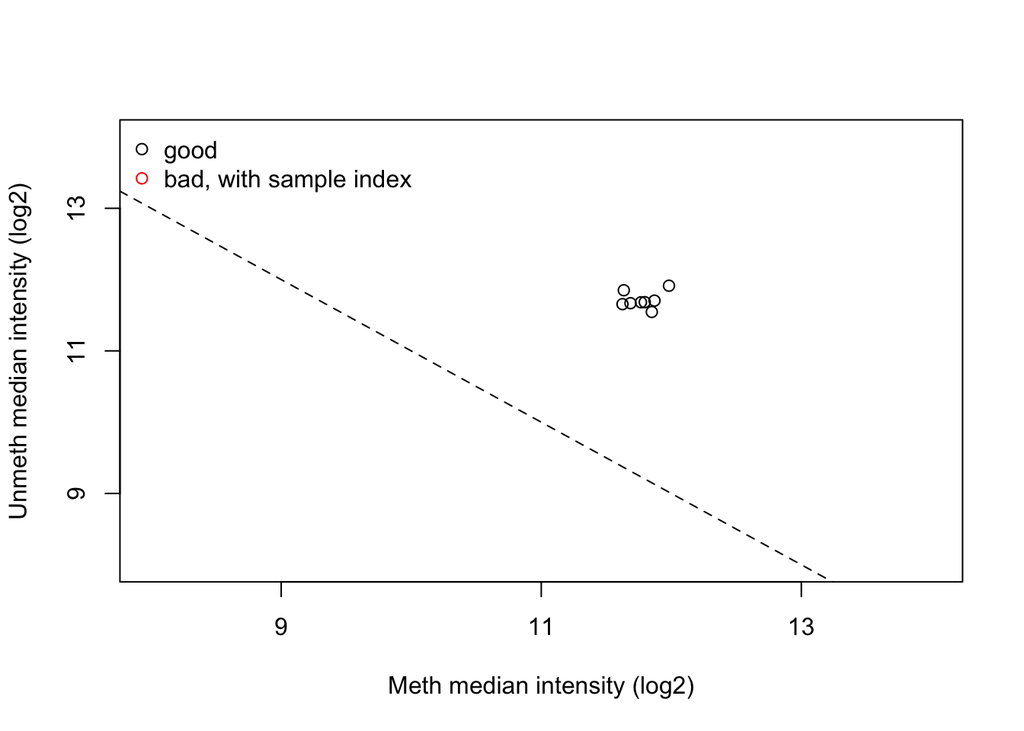

```r
plotQC(qc)
```

All the samples have high median methylation and unmethylation signals, i.e. they have good quality!

Then, we check the control probes. The Illumina guide (GenomeStudio_control_probes.pdf) tells us the expected intensities for each type of control probes.

To know the names and the numbers of the different types of control probes, we apply the getProbeInfo function to the RGset object.

```r
getProbeInfo(RGset, type = "Control")
```

```
## DataFrame with 848 rows and 4 columns
##         Address        Type       Color  ExtendedType
##     <character> <character> <character>   <character>
## 1      27630314    STAINING         Red    DNP (High)
## 2      43603326    STAINING      Purple     DNP (Bkg)
## 3      41666334    STAINING       Green Biotin (High)
## 4      34648333    STAINING        Blue  Biotin (Bkg)
## 5      63642461   EXTENSION         Red Extension (A)
## ...         ...         ...         ...           ...
## 844    65622344      NORM_T      Purple      Norm_T59
## 845    57640346      NORM_C       Green      Norm_C60
## 846    47715450      NORM_T      Purple      Norm_T60
## 847    28673402      NORM_C       Green      Norm_C61
## 848    13742412      NORM_T      Purple      Norm_T61
```

```r
df_TypeControl <- data.frame(getProbeInfo(RGset, type = "Control"))
str(df_TypeControl)
```

```
## 'data.frame':    848 obs. of  4 variables:
##  $ Address     : chr  "27630314" "43603326" "41666334" "34648333" ...
##  $ Type        : chr  "STAINING" "STAINING" "STAINING" "STAINING" ...
##  $ Color       : chr  "Red" "Purple" "Green" "Blue" ...
##  $ ExtendedType: chr  "DNP (High)" "DNP (Bkg)" "Biotin (High)" "Biotin (Bkg)" ...
```

```r
table(df_TypeControl$Type)
```

```
##
##  BISULFITE CONVERSION I BISULFITE CONVERSION II               EXTENSION
##                      12                       4                       4
##           HYBRIDIZATION                NEGATIVE         NON-POLYMORPHIC
##                       3                     613                       4
##                  NORM_A                  NORM_C                  NORM_G
##                      32                      61                      32
##                  NORM_T             RESTORATION           SPECIFICITY I
##                      61                       1                      12
##          SPECIFICITY II                STAINING          TARGET REMOVAL
##                       3                       4                       2
```

Then, we can use the controlSripPlot function to plot the intensity values of each type of controls probes in our samples

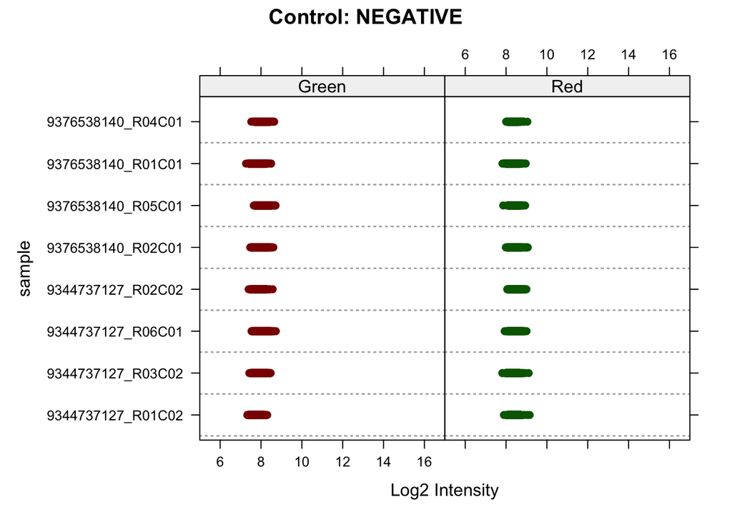

```r
controlStripPlot(RGset, controls="NEGATIVE")
```

Negative controls are all fine, as all below 1000 (log2(1000)=10) Note that there is a minor error in the package…green and red labels are swapped (only in R4.0.0 or higher). You can compare the results of these controls with the plots in Lesson 3 slides…everything looks fine!

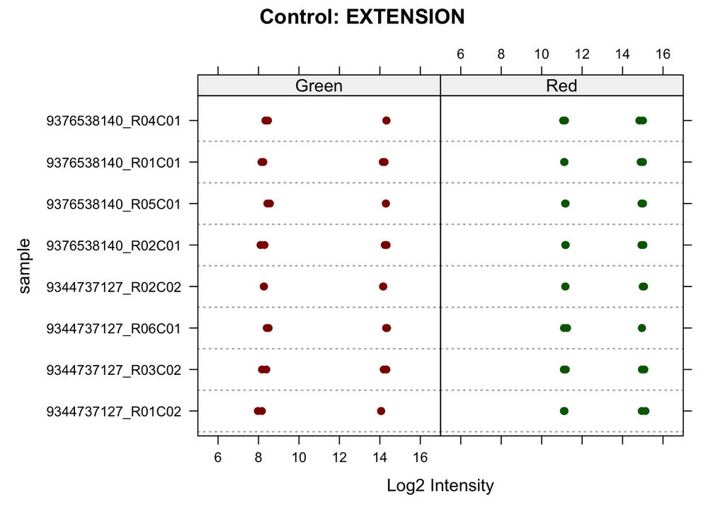

```r
controlStripPlot(RGset, controls="EXTENSION")
```

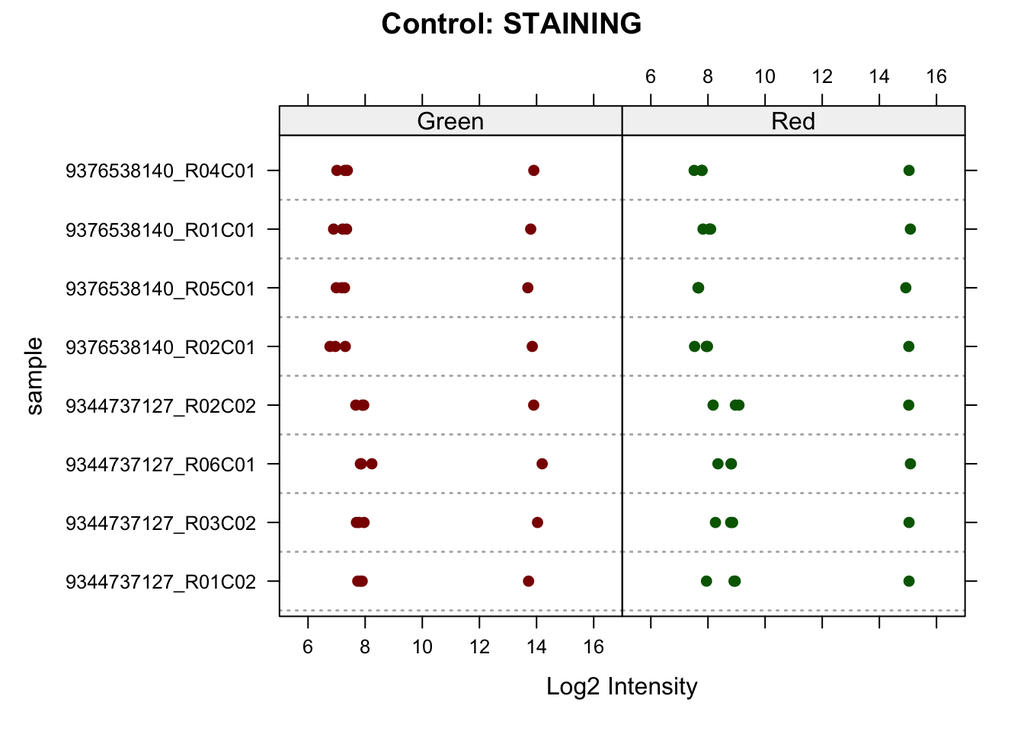

```r
controlStripPlot(RGset, controls="STAINING")
```

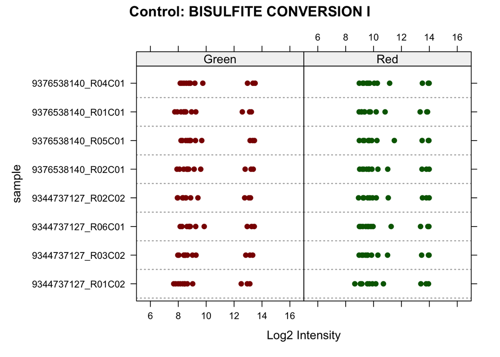

```r
controlStripPlot(RGset, controls="BISULFITE CONVERSION I")
```

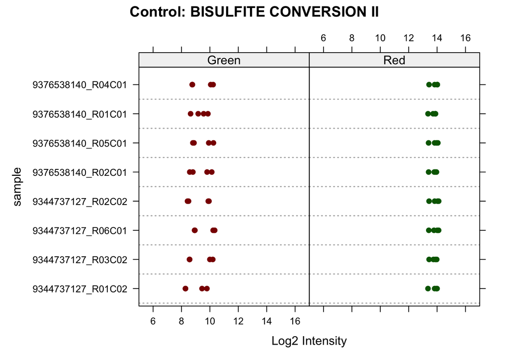

```r
controlStripPlot(RGset, controls="BISULFITE CONVERSION II")
```

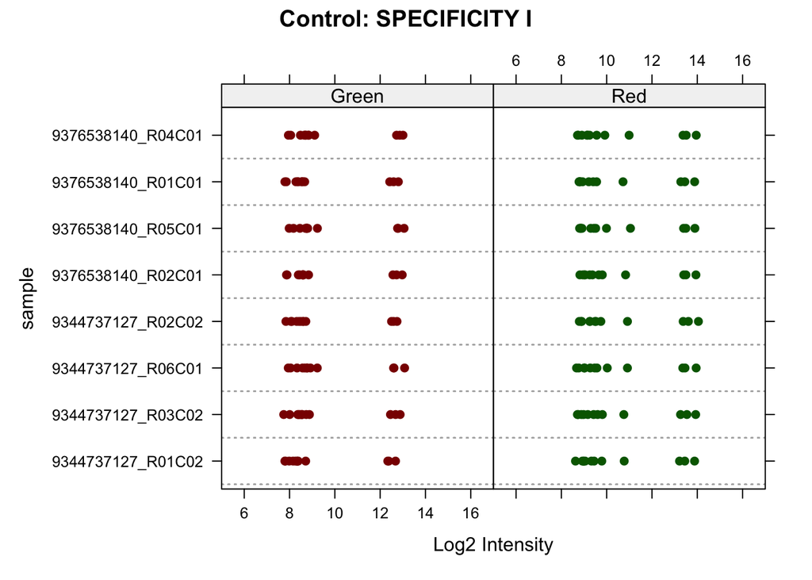

```r
controlStripPlot(RGset, controls="SPECIFICITY I")
```

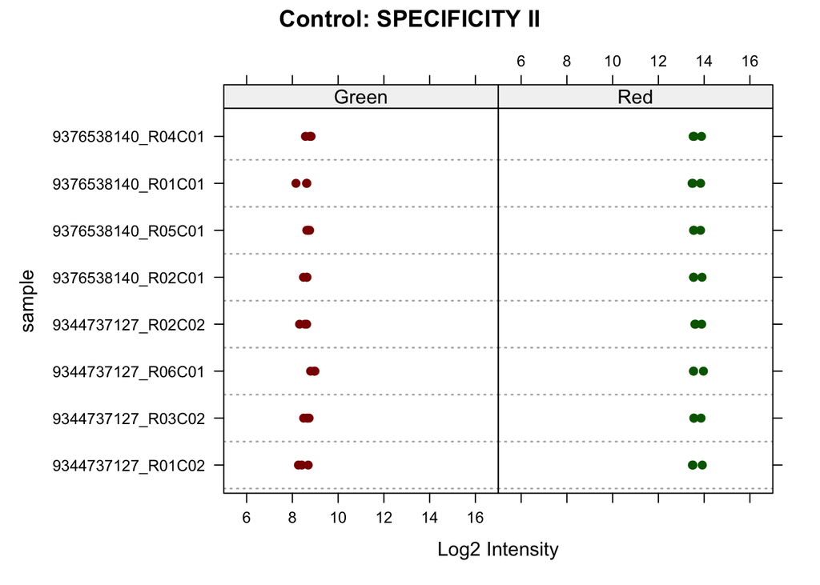

```r
controlStripPlot(RGset, controls="SPECIFICITY II")
```

# CHUNK 6: Detection p-value and filtering

```r
?detectionP
```

The detectionP() functions takes a bit. You can try to jump forward by directly loading the provided detP.RData object

```r
detP <- detectionP(RGset)
save(detP,file="detP.RData")
load("detP.RData") # or detP <- readRDS("detP.rds")
str(detP)
```

```
##  num [1:485512, 1:8] 0.402 0.716 0.547 0.988 0.488 ...
##  - attr(*, "dimnames")=List of 2
##   ..$ : chr [1:485512] "cg00050873" "cg00212031" "cg00213748" "cg00214611" ...
##   ..$ : chr [1:8] "9344737127_R01C02" "9344737127_R03C02" "9344737127_R06C01" "9344737127_R02C02" ...
```

```r
dim(detP)
```

```
## [1] 485512      8
```

```r
head(detP)
```

```
##            9344737127_R01C02 9344737127_R03C02 9344737127_R06C01
## cg00050873      4.015766e-01      2.073492e-02      4.330467e-01
## cg00212031      7.162885e-01      8.046760e-01      9.489066e-01
## cg00213748      5.466899e-01      6.145728e-01      8.861492e-01
## cg00214611      9.880296e-01      9.137651e-01      7.661954e-01
## cg00455876      4.883024e-01      1.702124e-06      4.287404e-04
## cg01707559      1.370547e-08      7.643943e-05      9.885952e-06
##            9344737127_R02C02 9376538140_R02C01 9376538140_R05C01
## cg00050873      5.664387e-02      5.609165e-01      9.507839e-01
## cg00212031      9.159458e-01      6.881236e-01      9.942861e-01
## cg00213748      8.796076e-01      8.779965e-01      9.784878e-01
## cg00214611      8.544530e-01      7.783007e-01      9.895595e-01
## cg00455876      2.317359e-01      6.077951e-02      5.994328e-03
## cg01707559      2.676472e-09      9.474742e-46      2.313609e-24
##            9376538140_R01C01 9376538140_R04C01
## cg00050873      9.599809e-01       0.00000e+00
## cg00212031      8.200040e-01       0.00000e+00
## cg00213748      4.552471e-01      9.05742e-149
## cg00214611      9.991770e-01       0.00000e+00
## cg00455876      1.267429e-03       0.00000e+00
## cg01707559      2.198449e-13       0.00000e+00
```

Note that in the detP object, rownames are the CpG probes names

Now we want to consider a detectionP threshold of 0.05

```r
failed <- detP>0.05
head(failed)
```

```
##            9344737127_R01C02 9344737127_R03C02 9344737127_R06C01
## cg00050873              TRUE             FALSE              TRUE
## cg00212031              TRUE              TRUE              TRUE
## cg00213748              TRUE              TRUE              TRUE
## cg00214611              TRUE              TRUE              TRUE
## cg00455876              TRUE             FALSE             FALSE
## cg01707559             FALSE             FALSE             FALSE
##            9344737127_R02C02 9376538140_R02C01 9376538140_R05C01
## cg00050873              TRUE              TRUE              TRUE
## cg00212031              TRUE              TRUE              TRUE
## cg00213748              TRUE              TRUE              TRUE
## cg00214611              TRUE              TRUE              TRUE
## cg00455876              TRUE              TRUE             FALSE
## cg01707559             FALSE             FALSE             FALSE
##            9376538140_R01C01 9376538140_R04C01
## cg00050873              TRUE             FALSE
## cg00212031              TRUE             FALSE
## cg00213748              TRUE             FALSE
## cg00214611              TRUE             FALSE
## cg00455876             FALSE             FALSE
## cg01707559             FALSE             FALSE
```

```r
dim(failed)
```

```
## [1] 485512      8
```

```r
table(failed)
```

```
## failed
##   FALSE    TRUE
## 3880745    3351
```

summary(failed) is particularly useful, as it returns the number of failed (TRUE) and not failed (FALSE) positions for each sample

```r
summary(failed)
```

```
##  9344737127_R01C02 9344737127_R03C02 9344737127_R06C01 9344737127_R02C02
##  Mode :logical     Mode :logical     Mode :logical     Mode :logical
##  FALSE:485013      FALSE:485084      FALSE:485032      FALSE:485049
##  TRUE :499         TRUE :428         TRUE :480         TRUE :463
##  9376538140_R02C01 9376538140_R05C01 9376538140_R01C01 9376538140_R04C01
##  Mode :logical     Mode :logical     Mode :logical     Mode :logical
##  FALSE:485071      FALSE:485092      FALSE:484989      FALSE:485415
##  TRUE :441         TRUE :420         TRUE :523         TRUE :97
```

Unfortunately, minfi does not provide any function that performs filtering of samples/probes on the basis of detection p-value! Other packages, like wateRmelon, allow to perform this action using convenient functions.

In any case, we can manually operate on the detP object to filter out failed samples and probes

First of all, we want to calculate the percentage of failed positions in each sample, and filter out those samples that have a % of failed positions higher than a certain threshold, for example 5%. To calculate the fraction of failed postions per sample, we can use the function colMeans() and apply it to the “failed” object that we have previoulsy created

```r
?colMeans
```

```
## Help on topic 'colMeans' was found in the following packages:
##
##   Package               Library
##   DelayedArray          /Library/Frameworks/R.framework/Versions/4.5-arm64/Resources/library
##   Matrix                /Library/Frameworks/R.framework/Versions/4.5-arm64/Resources/library
##   base                  /Library/Frameworks/R.framework/Resources/library
##   MatrixGenerics        /Library/Frameworks/R.framework/Versions/4.5-arm64/Resources/library
##   SparseArray           /Library/Frameworks/R.framework/Versions/4.5-arm64/Resources/library
##
##
## Using the first match ...
```

```r
means_of_columns <- colMeans(failed)
head(means_of_columns)
```

```
## 9344737127_R01C02 9344737127_R03C02 9344737127_R06C01 9344737127_R02C02
##      0.0010277810      0.0008815436      0.0009886470      0.0009536325
## 9376538140_R02C01 9376538140_R05C01
##      0.0009083195      0.0008650662
```

Each value corresponds to the ratio (number of TRUE)/(number of TRUE+FALSE) for each column (that is, for each sample)

For example, for sample 9344737127_R01C02 we had 499 TRUE and 485013 FALSE –> 499/(499+485013)= 0.001027781

We can decide, for example, to retain only the samples in which <5 % of sites has a bad detection p-value (greater than 0.05, the threshold that we used to calculate the object “failed”)

```r
samples_to_be_retained <- means_of_columns<0.05
samples_to_be_retained
```

```
## 9344737127_R01C02 9344737127_R03C02 9344737127_R06C01 9344737127_R02C02
##              TRUE              TRUE              TRUE              TRUE
## 9376538140_R02C01 9376538140_R05C01 9376538140_R01C01 9376538140_R04C01
##              TRUE              TRUE              TRUE              TRUE
```

Then I subset the RGset object in order to retain only the selected samples:

```r
RGset <- RGset[samples_to_be_retained]
RGset
```

```
## class: RGChannelSet
## dim: 622399 8
## metadata(0):
## assays(2): Green Red
## rownames(622399): 10600313 10600322 ... 74810490 74810492
## rowData names(0):
## colnames(8): 9344737127_R01C02 9344737127_R03C02 ... 9376538140_R01C01
##   9376538140_R04C01
## colData names(9): Sample_ID Sample_Well ... Basename filenames
## Annotation
##   array: IlluminaHumanMethylation450k
##   annotation: ilmn12.hg19
```

In this example, all the samples have < 5% of probes with a bad detection pValue, and therefore I can retain all the samples

The next step is to identify the probes that have a bad detectionP. To calculate the fraction of failed samples per probes, we can use the function rowMeans() and apply it to the “failed” object that we have previoulsy created

```r
means_of_rows <- rowMeans(failed)
head(means_of_rows)
```

```
## cg00050873 cg00212031 cg00213748 cg00214611 cg00455876 cg01707559
##      0.750      0.875      0.875      0.875      0.375      0.000
```

Each value corresponds to the ratio (number of TRUE)/(number of TRUE+FALSE) for each row (that is, for each probe)

```r
head(failed)
```

```
##            9344737127_R01C02 9344737127_R03C02 9344737127_R06C01
## cg00050873              TRUE             FALSE              TRUE
## cg00212031              TRUE              TRUE              TRUE
## cg00213748              TRUE              TRUE              TRUE
## cg00214611              TRUE              TRUE              TRUE
## cg00455876              TRUE             FALSE             FALSE
## cg01707559             FALSE             FALSE             FALSE
##            9344737127_R02C02 9376538140_R02C01 9376538140_R05C01
## cg00050873              TRUE              TRUE              TRUE
## cg00212031              TRUE              TRUE              TRUE
## cg00213748              TRUE              TRUE              TRUE
## cg00214611              TRUE              TRUE              TRUE
## cg00455876              TRUE              TRUE             FALSE
## cg01707559             FALSE             FALSE             FALSE
##            9376538140_R01C01 9376538140_R04C01
## cg00050873              TRUE             FALSE
## cg00212031              TRUE             FALSE
## cg00213748              TRUE             FALSE
## cg00214611              TRUE             FALSE
## cg00455876             FALSE             FALSE
## cg01707559             FALSE             FALSE
```

For example, for the probe cg00050873 we had 6 TRUE and 2 FALSE –> 6/(6+2)= 0.750

We can decide, for example, to retain only the probes in which <1 % of samples has a bad detection p-value (greater than 0.05, the threshold that we used to calculate the object “failed”)

```r
probes_to_be_retained <- means_of_rows<0.01
head(probes_to_be_retained)
```

```
## cg00050873 cg00212031 cg00213748 cg00214611 cg00455876 cg01707559
##      FALSE      FALSE      FALSE      FALSE      FALSE       TRUE
```

```r
str(probes_to_be_retained)
```

```
##  Named logi [1:485512] FALSE FALSE FALSE FALSE FALSE TRUE ...
##  - attr(*, "names")= chr [1:485512] "cg00050873" "cg00212031" "cg00213748" "cg00214611" ...
```

Note that the “probes_to_be_retained” object is a vector of logical vectors with names (that is, each element of the vector has a name). We can access to these names using the function names()

```r
names(probes_to_be_retained[1:10])
```

```
##  [1] "cg00050873" "cg00212031" "cg00213748" "cg00214611" "cg00455876"
##  [6] "cg01707559" "cg02004872" "cg02011394" "cg02050847" "cg02233190"
```

returns the names of the first 10 probes

```r
table(probes_to_be_retained)
```

```
## probes_to_be_retained
##  FALSE   TRUE
##   1121 484391
```

counts the number of TRUE and FALSE in the vector.

Now I want to select the probes that I want to remove: these are the probes with “FALSE” in the probes_to_be_retained vector

```r
probes_to_be_removed <- probes_to_be_retained[probes_to_be_retained==FALSE]
length(probes_to_be_removed)
```

```
## [1] 1121
```

```r
names_probes_to_be_removed <- names(probes_to_be_removed)
head(names_probes_to_be_removed)
```

```
## [1] "cg00050873" "cg00212031" "cg00213748" "cg00214611" "cg00455876"
## [6] "cg02004872"
```

Unfortunately, as we will see in the next lesson, most of the normalization procedures implemented in minfi work on the RGset object and do not like missing probes. If the number of bad probes is low, they will not affect the normalization procedures. Therefore, we can retain the bad probes at this step, but save them in order to remove them after the normalizaion step.

```r
save(names_probes_to_be_removed,file="names_probes_to_be_removed.RData")
```

Exercise 2: load the RGset_CRC.RData or RGset_CRC.rds object (this is from an IlluminaHumanMethylationEPIC experiment and you will nee to install the IlluminaHumanMethylationEPICmanifest from Bioconductor). How many samples does it contain? Use plotQC the check the quality of the samples and check NEGATIVE and EXTENSION controls…do you see anything wrong with these data?